# Sparse regression with a proximal operator

An L1 penalty can set regression coefficients exactly to zero. Its corner at zero calls for a nonsmooth optimization method. On Euclidean space, the exact proximal map is coordinatewise soft thresholding, so this problem provides a transparent introduction to `riem.problem.composite()`. The same interface supports other manifolds when the supplied proximal map solves the corresponding manifold-distance subproblem.

See the regression introduction for the basic problem interface and the constraints and nonsmooth guide for the distinction between an intrinsic proximal map and ambient shrinkage.

## Data and scaling

The [`mtcars` data](https://stat.ethz.ch/R-manual/R-devel/library/datasets/html/mtcars.html) contain 32 cars from 1973–74. We use fuel consumption (`mpg`, miles per US gallon) and five continuous predictors: displacement (`disp`, cubic inches), horsepower (`hp`), rear axle ratio (`drat`), weight (`wt`, thousands of pounds), and quarter-mile time (`qsec`). These selected columns have no missing values. The data come with R, so this example needs no download. Data sources and reproducibility records attribution.

```r
predictors <- c("disp", "hp", "drat", "wt", "qsec")
cars <- datasets::mtcars
stopifnot(!anyNA(cars[, c("mpg", predictors)]))
X <- scale(as.matrix(cars[, predictors]))
y <- cars$mpg - mean(cars$mpg)
n <- nrow(X)
p <- ncol(X)
registered <- list(
  X = torch_tensor(X, dtype = torch_float64(), device = "cpu"),
  y = torch_tensor(y, dtype = torch_float64(), device = "cpu"),
  n = n
)
```

`scale()` subtracts each column mean and divides by its sample standard deviation. Standardization makes a common penalty meaningful across different predictor units. Centering the response removes the unpenalized intercept; on the original response scale it is restored by adding `mean(cars$mpg)` to predictions. No train/test split is used: this is an optimization illustration, not evidence of predictive superiority or a procedure for selecting a penalty.

## Objective and exact proximal map

For each penalty *λ*, solve

$$\min_{\beta\in\mathbb R^5}
\frac{1}{2n}\|X\beta-y\|_2^2 + \lambda\|\beta\|_1.$$

The smooth gradient is *X*<sup>*T*</sup>(*X**β* − *y*)/*n*. For a step *t* > 0, the Euclidean proximal map is sign (*q*)max (|*q*|−*t**λ*, 0), applied coordinatewise. It exactly minimizes the nonsmooth term plus ∥*β* − *q*∥<sup>2</sup>/(2*t*). On a curved manifold, applying this operation and then projecting would generally solve a different problem.

```r
make_problem <- function(lambda) {
  riem.problem.composite(
    manifold.euclidean(p),
    fn = function(beta, data) {
      (data$X$matmul(beta) - data$y)$square()$mean() / 2
    },
    egrad = function(beta, data) {
      data$X$t()$matmul(data$X$matmul(beta) - data$y) / data$n
    },
    nonsmooth = function(beta, data) beta$abs()$sum() * data$lambda,
    prox = function(q, step, data) {
      q$sign() * (q$abs() - step * data$lambda)$clamp(min = 0)
    },
    data = c(registered, list(lambda = lambda))
  )
}
```

The explicit gradient avoids constructing an automatic differentiation graph at every iteration. All objective tensors and the penalty are registered as problem data.

## Follow a short penalty path

The smallest penalty for which zero satisfies the optimality conditions is *λ*<sub>max</sub> = ∥*X*<sup>*T*</sup>*y*/*n*∥<sub>∞</sub>. We start there and decrease the penalty through five values. Each penalty defines a separate fixed objective. Warm starting reuses the preceding solution as the next initial point.

```r
lambda_max <- max(abs(drop(crossprod(X, y)) / n))
penalty_ratio <- c(1, 0.5, 0.2, 0.1, 0.05)
lambdas <- lambda_max * penalty_ratio
L <- max(eigen(crossprod(X) / n, symmetric = TRUE, only.values = TRUE)$values)
initial <- torch_zeros(p, dtype = torch_float64(), device = "cpu")
fits <- vector("list", length(lambdas))
for (j in seq_along(lambdas)) {
  fits[[j]] <- riem.optimize(
    make_problem(lambdas[j]), initial, method = "proximal_gradient",
    control = list(max_iterations = 1500, step_size = 1.8 / L,
                   proximal_tolerance = 1e-5),
    device = "cpu"
  )
  initial <- fits[[j]]$point
}
coefficients <- vapply(fits, function(fit) as.numeric(fit$point), numeric(p))
rownames(coefficients) <- predictors
colnames(coefficients) <- paste0("ratio_", penalty_ratio)
round(coefficients, 4)
```

```
#>      ratio_1 ratio_0.5 ratio_0.2 ratio_0.1 ratio_0.05
#> disp       0   -0.3492   -0.0773    0.0000     0.0000
#> hp         0   -0.4751   -1.5275   -1.6438    -1.4334
#> drat       0    0.0000    0.2121    0.5500     0.7180
#> wt         0   -1.9916   -2.9575   -3.1918    -3.4098
#> qsec       0    0.0000    0.0000    0.2284     0.5855
```

```r
status <- data.frame(
  penalty_ratio = penalty_ratio,
  lambda = lambdas,
  objective = vapply(fits, function(fit) fit$objective, numeric(1)),
  iterations = vapply(fits, function(fit) fit$iterations, numeric(1)),
  proximal_residual = vapply(fits, function(fit) fit$proximal_residual, numeric(1)),
  termination = vapply(fits, function(fit) fit$termination, character(1))
)
status
```

```
#>   penalty_ratio    lambda objective iterations proximal_residual
#> 1          1.00 5.0659212 17.594487          0      0.000000e+00
#> 2          0.50 2.5329606 14.175585        191      9.539852e-06
#> 3          0.20 1.0131842  8.447814        198      9.843224e-06
#> 4          0.10 0.5065921  5.834250        118      9.685077e-06
#> 5          0.05 0.2532961  4.344771        135      9.988864e-06
#>                   termination
#> 1 converged_proximal_residual
#> 2 converged_proximal_residual
#> 3 converged_proximal_residual
#> 4 converged_proximal_residual
#> 5 converged_proximal_residual
```

Here *L* is the largest eigenvalue of the smooth Hessian. The initial step `1.8 / L` is below `2 / L`; the solver also checks sufficient decrease and backtracks when necessary. The stopping rule uses the proximal gradient mapping, not the smooth gradient alone. An iteration limit would mean more work is needed; we verify successful termination below.

## Visualize coefficients as the penalty decreases

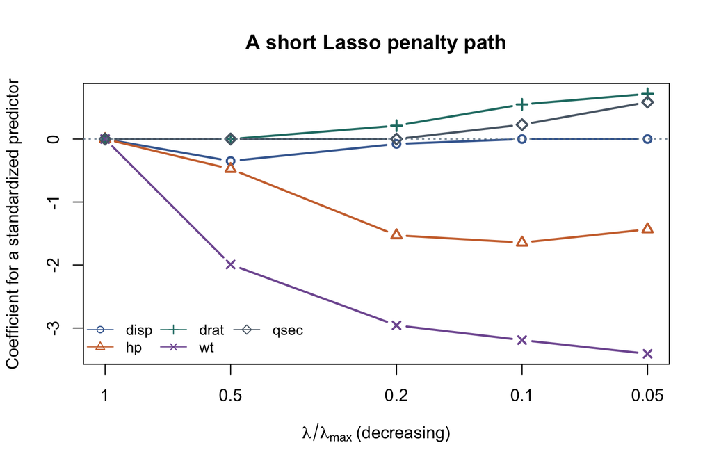

The paths are coefficients per sample-standard-deviation change in each predictor. Zero coefficients are exact soft-thresholding results.

## Independent verification with coordinate descent

For comparison, implement cyclic coordinate descent directly in base R. It updates one coefficient at a time using the residual with that coordinate removed. The denominator is the actual squared column norm divided by `n`; with sample-standard-deviation scaling it is `(n - 1) / n`, not one.

```r
soft_threshold <- function(z, threshold) sign(z) * max(abs(z) - threshold, 0)
coordinate_descent <- function(lambda) {
  beta <- numeric(p)
  squared_norm <- colSums(X^2) / n
  for (iteration in seq_len(20000)) {
    previous <- beta
    for (j in seq_len(p)) {
      partial_residual <- y - drop(X %*% beta) + X[, j] * beta[j]
      score <- sum(X[, j] * partial_residual) / n
      beta[j] <- soft_threshold(score, lambda) / squared_norm[j]
    }
    if (max(abs(beta - previous)) < 1e-11) return(beta)
  }
  stop("Independent coordinate descent did not converge.")
}
reference <- vapply(lambdas, coordinate_descent, numeric(p))
coefficient_error <- apply(abs(coefficients - reference), 2, max)
```

At a nonzero coefficient, the gradient plus *λ* times the coefficient sign must vanish. At zero, the gradient must lie in [−*λ*, *λ*]. These are the Lasso optimality conditions. Checking them independently avoids relying only on a solver’s success label.

```r
kkt_residual <- function(beta, lambda) {
  gradient <- drop(crossprod(X, drop(X %*% beta) - y)) / n
  active <- abs(beta) > 1e-8
  residual <- pmax(abs(gradient) - lambda, 0)
  residual[active] <- abs(gradient[active] + lambda * sign(beta[active]))
  max(residual)
}
kkt <- vapply(seq_along(lambdas), function(j) {
  kkt_residual(coefficients[, j], lambdas[j])
}, numeric(1))
comparison <- data.frame(penalty_ratio = penalty_ratio,
                        maximum_coefficient_error = coefficient_error,
                        independent_kkt_residual = kkt)
comparison
```

```
#>            penalty_ratio maximum_coefficient_error independent_kkt_residual
#> ratio_1             1.00              0.000000e+00             0.000000e+00
#> ratio_0.5           0.50              8.974114e-05             7.445769e-06
#> ratio_0.2           0.20              9.967446e-05             7.973211e-06
#> ratio_0.1           0.10              6.302427e-05             6.844356e-06
#> ratio_0.05          0.05              6.500111e-05             7.059039e-06
```

```r
stopifnot(all(status$termination == "converged_proximal_residual"),
          max(coefficient_error) < 5e-4,
          max(kkt) < 2e-5,
          max(abs(coefficients[, 1])) < 1e-8)
```

The tolerances allow small numerical differences between algorithms while requiring close coefficient agreement and small optimality residuals. The correlated predictors in this small historical dataset make coefficient paths sensitive to modeling choices. A predictive analysis would need an appropriate validation design, with preprocessing estimated within each training split.

## Choose a device for your own run

This article explicitly uses CPU float64. In `riem.optimize()`, change `device` to `"auto"` for automatic discovery, retain `"cpu"` to force CPU even when CUDA is available, or choose `"cuda:0"` on a compatible workstation. Registered data move to the resolved device together with the point.

```r
# Replace the device argument inside the loop above:
# device = "auto"    # automatic selection preserving the requested precision
# device = "cpu"     # explicit CPU override
# device = "cuda:0"  # explicit first CUDA GPU; errors if unavailable
```